# Movie Boxoffice Predictions 1

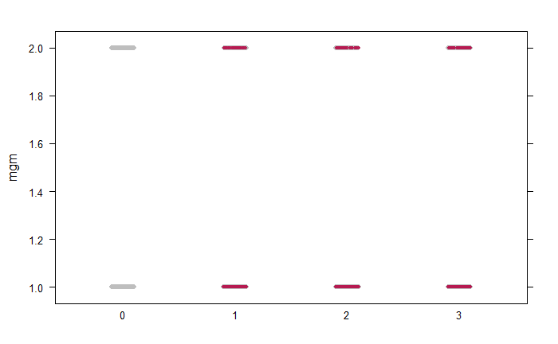

`r`r densityplot(imputations_cart, ~ twentieth_century | .imp)

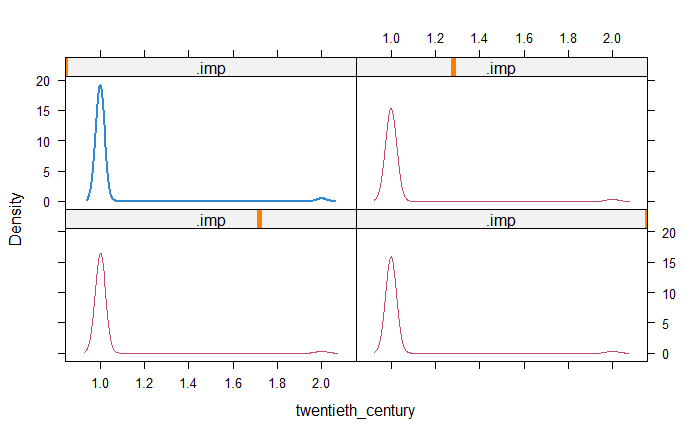

`r`r stripplot(imputations_cart, twentieth_century, col = c(, mdc(2)), pch = c(1, 20))

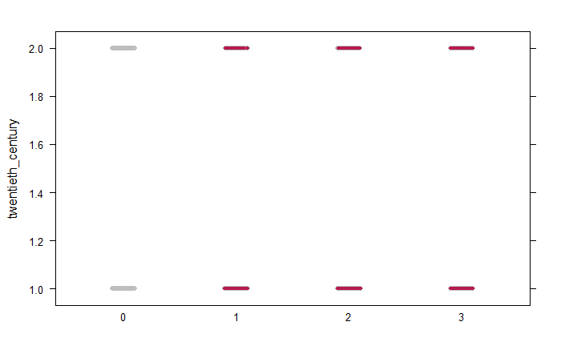

`r`r densityplot(imputations_cart, ~ warner_bros | .imp)

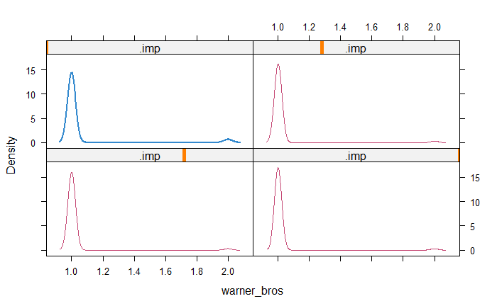

`r`r stripplot(imputations_cart, warner_bros, col = c(, mdc(2)), pch = c(1, 20))

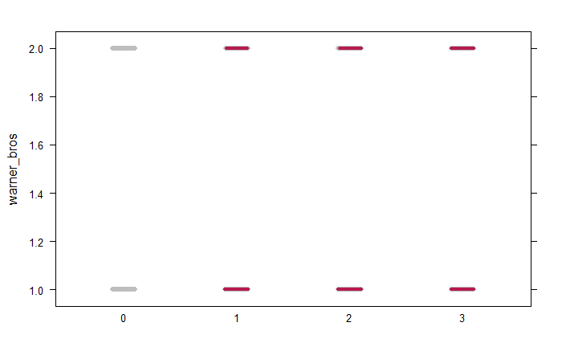

`r`r densityplot(imputations_cart, ~ universal | .imp)

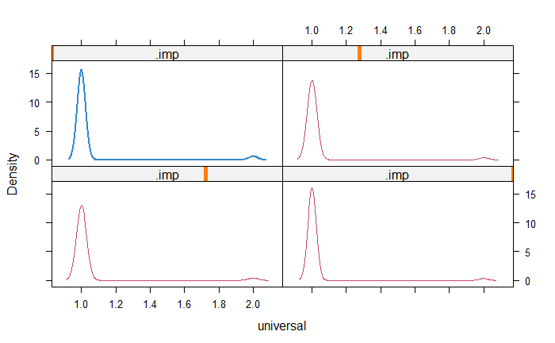

`r`r stripplot(imputations_cart, universal, col = c(, mdc(2)), pch = c(1, 20))

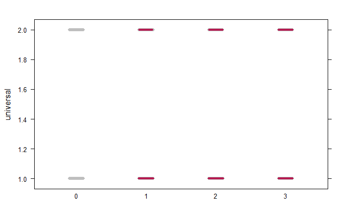

`r`r densityplot(imputations_cart, ~ columbia | .imp)

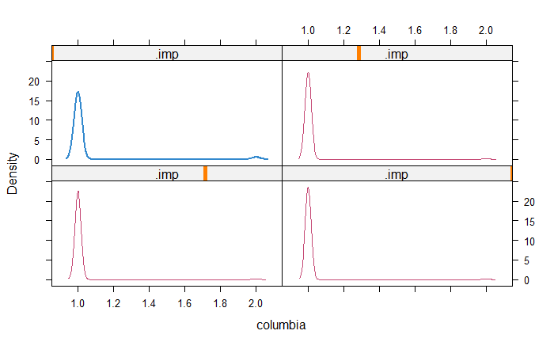

`r`r stripplot(imputations_cart, columbia, col = c(, mdc(2)), pch = c(1, 20))

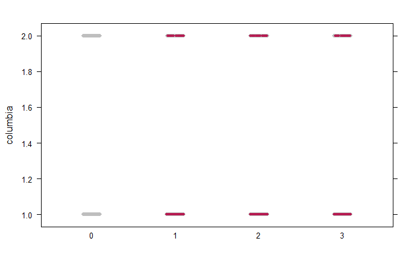

`r`r densityplot(imputations_cart, ~ rko_radio | .imp)

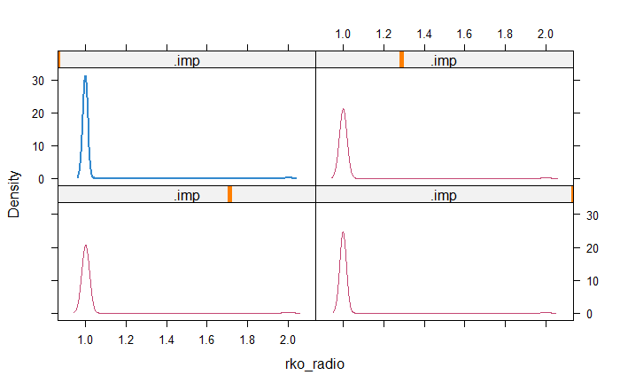

`r`r stripplot(imputations_cart, rko_radio, col = c(, mdc(2)), pch = c(1, 20))

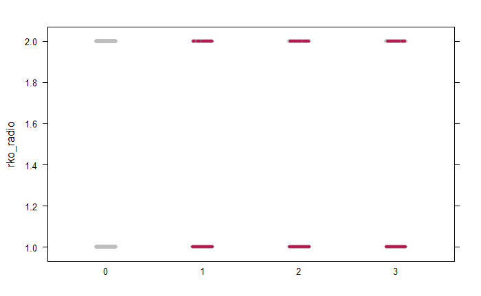

`r`r densityplot(imputations_cart, ~ united_artists | .imp)

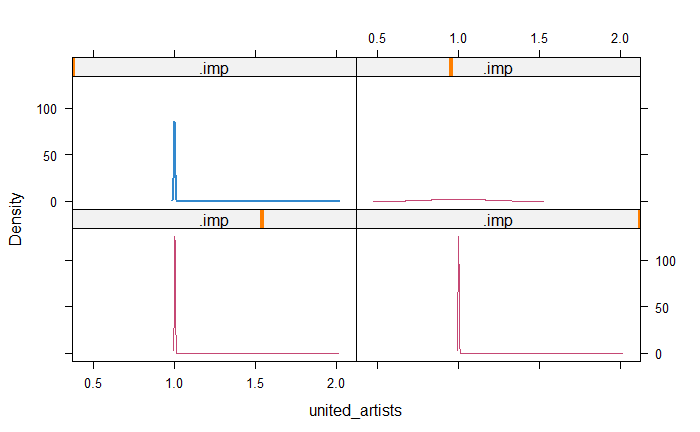

`r`r stripplot(imputations_cart, united_artists, col = c(, mdc(2)), pch = c(1, 20))

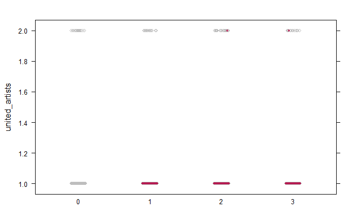

`r`r densityplot(imputations_cart, ~ walt_disney | .imp)

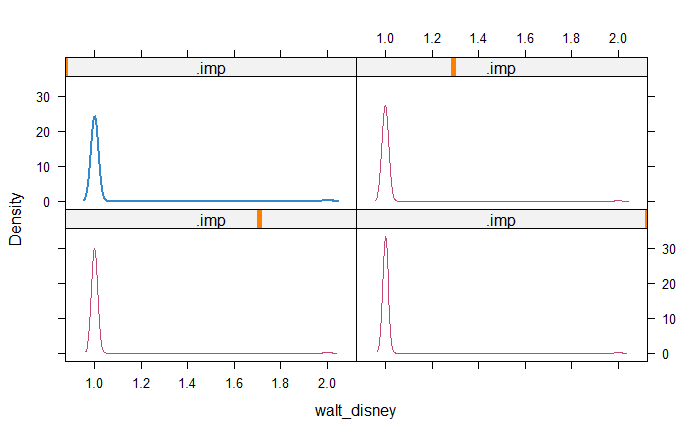

`r`r stripplot(imputations_cart, walt_disney, col = c(, mdc(2)), pch = c(1, 20))

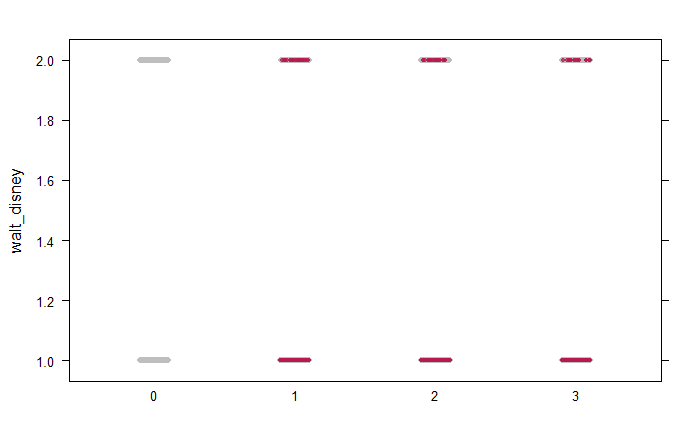

`r`r densityplot(imputations_cart, ~ new_line_cinema | .imp)

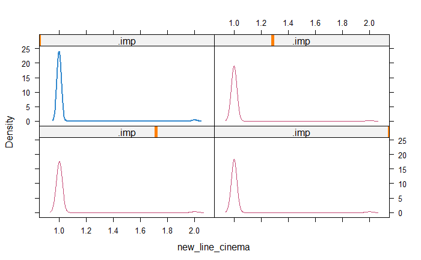

`r`r stripplot(imputations_cart, new_line_cinema, col = c(, mdc(2)), pch = c(1, 20))

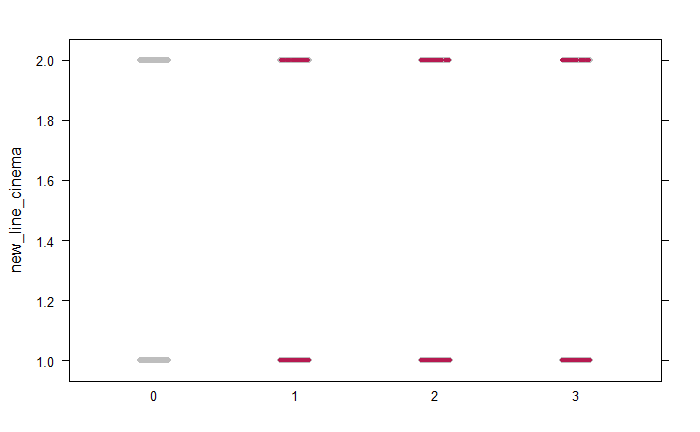

`r`r densityplot(imputations_cart, ~ prod_size | .imp)

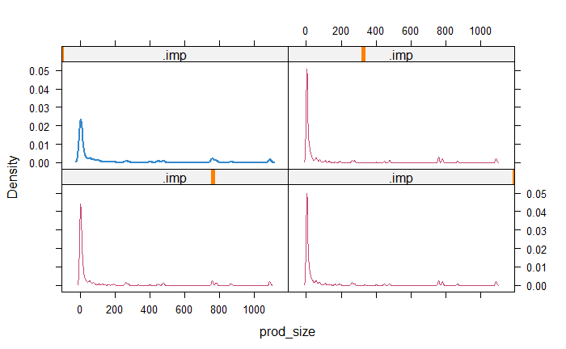

`r`r stripplot(imputations_cart, prod_size, col = c(, mdc(2)), pch = c(1, 20))

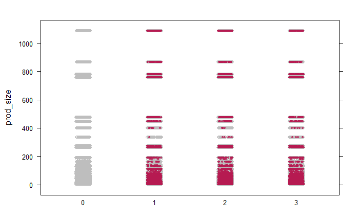

`r`r densityplot(imputations_cart, ~ num_production_companies | .imp)

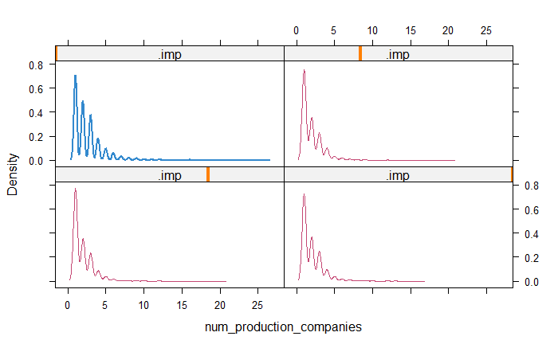

`r`r stripplot(imputations_cart, num_production_companies, col = c(, mdc(2)), pch = c(1, 20))

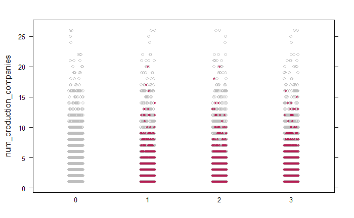

`r`r densityplot(imputations_cart, ~ production_country | .imp)

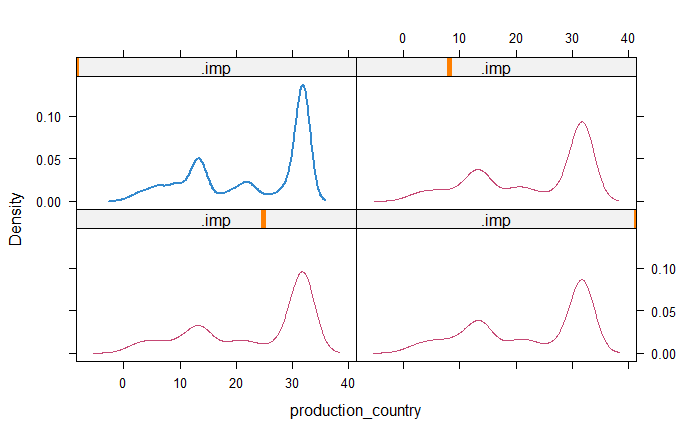

`r`r stripplot(imputations_cart, production_country, col = c(, mdc(2)), pch = c(1, 20))

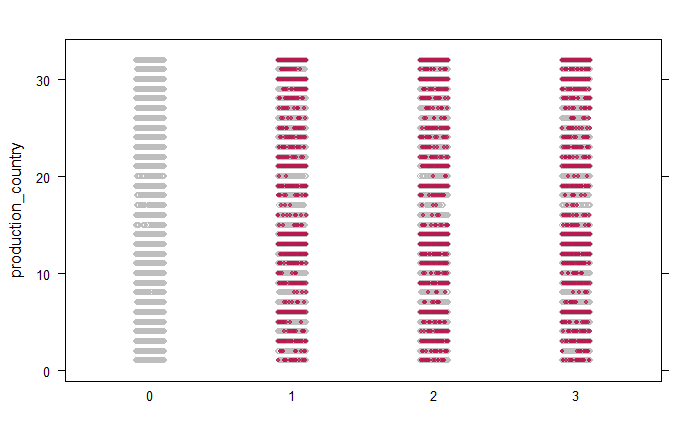

In general all of the imputed data is close to the median, the mean is generally skewed because of some outliers so it makes sense that the imputations are close to the median. The key variables to look at in terms of imputations are mainly budget, meterClass, meterScore. We know that meterClass and meterScore are highly correlated so as a result we want both of their density graphs to look similar (less imputations in 75+ meterScore, should result in less imputations in the certified fresh column for meterClass). For budget we would prefer the imputations to be lower when compared to the data set as the movies with recorded data will generally have a higher budget and their movie will be made by bigger production companies who disclose the budget.